# Travel Safety for US citizens

project team members

1/22/2022

## Summary Information

This is a summary paragraph that details important information about the data. The most recent update to this data was in 12/31/2020. This data includes 8167 different cities. There are 120 causes of death in the data with the most common cause of death being Homicide. The data has an average of 2.5466205 deaths added to the dataset each day.

source(“aggregate.R”)

## Aggregated Table script

**death_per_city**: By ranking the number of deaths from lowest to highest, we can observe the ranking of safety for each city. The data set for “death_per_city” will reveal the name of the city and next to it, the number of deaths that occurred in that city.

**types_of_death**: This data set reveals the Cause of Death on the first column and the occurrence of each of the causes on the second column. We would need this data to be aware of which aspect we need to be cautious of, when we travel around.

source(“barchart.R”)

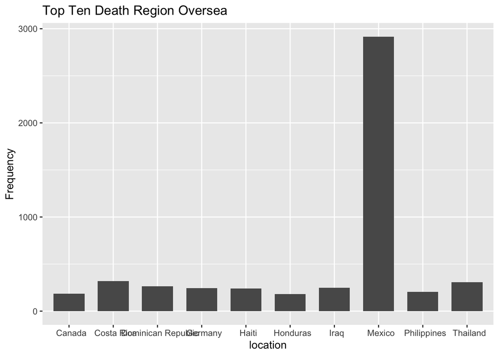

**Description** : The bar chart have list out the top 10 region that most U.S citizens die over sea. The purpose of the graph is to shows the danger of each region so people can avoid to travel to these location on the graph. As the graph shows, Mexico have approximately ten times higher than the other.

# Travel Safety for US citizens

project team members

1/22/2022

## Travel Safety for US citizens: Report

https://data.world/datasets/travel https://data.world/kgarrett/us-citizen-deaths-overseas

**Authors**

Howard Lin Irene (Jeongmin) Lee Jacob Kim Chase Harmon

**Affiliation** INFO-201: Technical Foundations of Informatics - The Information School - University of Washington

**Date** Winter 2022

**Abstract** Our main goal with this project was to determine which locations were safest to travel for a US citizen. We are concerned with this because it could be a potentially helpful tool for people looking to travel outside the US, but want to stay relatively safe as well. We did this study using data of all US citizens that have died oversea.

**Keywords** Travel, Death, Safety, Foreign Country, US citizen

**Introduction** This project attempts to determine which cities are most and least safe using statistics given by the US government which details where and how US citizens outside the country have died. These statistics are not well formatted at a quick glance which gave us the idea of creating this project. We can use these statistics and compared to travel information which show approximately how many US citizens traveled to different countries. With these two values our project attempts to create a safety rating for each country and city and determine which countries are safest to travel to. These statistics are all laid out in various charts and tables in this project.

**Design Situation**

*Framing*: The topic of concern is travel safety and our perception of safety itself. Determining what places are safe has already been done before however, top websites usually use a complex algorithm in which they compare things like covid performance, peace index and average wealth. Adding such abstract values together into a single number creates some bias. We hope our data fixes some of those biases as well as gives accurate information for travel safety.

*Direct Stakeholder*: The direct stakeholders are tourists, immigrants or people who are planning to travel overseas. The datasets list out the city and cause of death for each case, after analyzing it it would become a suggestion or consideration for the stakeholder’s safety.

*Indirect stakeholders*: The indirect stakeholders will focus mainly on the tourism rate of each city. When choosing a place to travel people normally pick the one that assures their personal safety. Places with lower death rates will be more popular and willing to travel than places with higher death rates. This effect will also impact cities GDP by personal consumption or Government spending.

*Possible harms*: The possible harm would be the reputation of each city because people would be willing to know the safety rate for each city and make a tag for the danger’s one. It will impact the most on tourism and indirectly affect the economics for those cities.

*Benefits*: People can better reduce risks of death by either avoiding to choose countries with the highest death rates or choosing the countries with the lowest death rates.

*Human Value*: In this project we are helping other people determine where to travel and what places are safe versus unsafe.

Here are some websites with similar projects:

https://www.bhtp.com/blog/safest-places-to-travel https://alliance-primo.hosted.exlibrisgroup.com/permalink/f/lvbsh/TN_cdi_pubmedcentral_primary_oai_pubmedcentral_nih_gov_1403624 https://alliance-primo.hosted.exlibrisgroup.com/permalink/f/lvbsh/TN_cdi_pubmed_primary_2039100

**3.0 Research questions**

Which overseas city has the lowest death rate for US citizens? Which overseas city has the highest death rate for US citizens? What is the main cause of death for US citizens? Which city is worth the risk of travel? Which city has improved the most? Which one has gotten worse?

The motivation for these questions is to determine which cities will be the safest place to travel overseas and which one is not. Within our dataset, each case came with a reason and where did it happen. This research is important to us because being a resident that lives on US territory we are able to travel all around the world, but before we travel, determining a safe destination could save our life or avoid danger. Our research will also determine which cities have gotten progressively safer or more dangerous for US citizens which may be important to someone who is planning on moving to that country or staying there for an extended period of time.

**The Datas** *Size and complexity*:

Our Data set contains 13045 deaths with the location, date, and cause of each death. However, we also added a smaller data set with each location and the amount of US citizens that have travelled to that area.

*Who or what is represented in the data?*:

The data represents the deaths outside of the US and the amount of people who travel to different places outside of the US.

*What is an observation? What variables are included (and excluded)*?

The observation is the death of a US citizen outside of the country. The main variables included are time of death, cause of death, and place of death. The time of death is specified to the minute, the cause of death is a somewhat descriptive expression and the place of death is specified to the city and country.

*Who collected the data? When? For what purpose? How was the data collection effort funded? Who is likely to benefit from the data or make money?*

The US government collected the data. They collect the data every time someone dies outside of the country and post it to travel.state.gov . The purpose for this data collection is to provide information to people who are going to travel abroad by giving them a detailed layout of what happens should they die when they are outside of the country. The data collection is funded by the government itself and has been funded since 2002. The people most likely to benefit from this data are people who are going to travel abroad or people who are going to live abroad. They will have information about what happens if they die when out of the country. It is not apparent if anyone profits from this data however I would assume not.

*How was the data validated and held secure? Is it credible and trustworthy?*

The data is validated and held secure through the US government. This data is very credible and trustworthy because the US government is legally responsible and required to give us this data.

*How did you obtain the data? Do you credit the source of the data?*

We obtained this data by looking for data sets online and found this one to be quite important, but also not formatted in a way in which a normal person would be able to obtain any reasonable information on it.

**Expected Implications**

The main expected implication is for normal people deciding where to travel to. People like you and me can accurately look at the risk involved with each country and determine if that risk is worth the potential benefit of visiting that country. Not only that, people looking to immigrate to another country may look at this data to see which countries are objectively safest. Policy makers can also look at this data to see certain ways in which to make their country safer. A consistent cause of death or consistent deaths within a city may be a red flag to policy makers within that country. A possible implication with our research may be for us to reconsider what places are truly dangerous or not. There are lots of biases against specific countries in the world and our data may reveal them to be false or reinforce them further.

**Limitations** The main limitation is that we are not able to determine the plan and what are they doing during the trip. For some reason the people might implement something with high risk danger during their lifetime. Not being able to determine their motivation would affect the accuracy of our research question because people were traveling for different reasons. The reasons that include high risk dangers would increase their chance of dying and make our data biased against certain cities. Another limitation is that we are only measuring death. This means other causes of hardship like injuries or theft are not included in this data and will decrease our accuracy in determining which places are safer.

**summary** This is a summary paragraph that details important information about the data. The most recent update to this data was in 12/31/2020. This data includes 8167 different cities. There are 120 causes of death in the data with the most common cause of death being Homicide. The data has an average of 2.5466205 deaths added to the dataset each day.

**Aggregated Table script** *death per city*: By ranking the number of deaths from lowest to highest, we can observe the ranking of safety for each city. The data set for “death_per_city” will reveal the name of the city and next to it, the number of deaths that occurred in that city.

```
## # A tibble: 8,167 x 3
##    City                                                     num_of_death Country
##    <chr>                                                           <int> <chr>
##  1 ""                                                                  4 ""
##  2 "'strada Provinciale 99' -  Km. 1.3 -  Tortona -  Aless~            1 "Italy"
##  3 " -  Dominican Republic"                                            1 "Repub~
##  4 " -  Thailand"                                                      2 "Thail~
##  5 " - Agua Prieta - Sonora -  Mexico"                                 1 "Mexic~
##  6 " - Atacames - Esmeraldas -  Ecuador"                               1 "Ecuad~
##  7 " - Cd. Juarez - Chihuahua -  Mexico"                               1 "Mexic~
##  8 " - kashan -  Iran"                                                 1 "Iran"
##  9 " - Khartoum - Khartoum -  Sudan"                                   1 "Sudan"
## 10 " - Mexicali - Baja California -  Mexico"                           1 "Mexic~
## # ... with 8,157 more rows
```

*types of death*: This data set reveals the Cause of Death on the first column and the occurrence of each of the causes on the second column. We would need this data to be aware of which aspect we need to be cautious of, when we travel around.

```
## # A tibble: 120 x 2
##    Cause.of.Death      num_per_cause
##    <chr>                       <int>
##  1 Homicide                     2759
##  2 Suicide                      2096
##  3 Drowning                     1864
##  4 Other Accident               1855
##  5 Veh. Accid-Auto              1808
##  6 Veh. Accident-Auto            887
##  7 Veh. Accid-Motorcy.           503
##  8 Air Accident                  428
##  9 Terrorist Action              396
## 10 Drug-Related                  359
## # ... with 110 more rows
```

*travel_to_death_ratio*: This data reveals which areas are safest to travel to based on a ratio which is the amount of people that travelled to this area in 2018 and the amount of deaths in this area overall. This ratio, although arbitrary, can be used to compare areas against one another, for a lower ratio means less people have died in your area despite a large amount of people entering. This dataset gives a slightly different approach to determining which places are safest and most dangerous.

```
## # A tibble: 90 x 5
##    Country      num_of_death World_area_code Number_of_visits travel_to_death_r~
##    <chr>               <dbl>           <dbl>            <dbl>              <dbl>
##  1 Ontario                 6             936            53548           0.000112
##  2 Quebec                  4             941            23029           0.000174
##  3 Manitoba                1             926             3913           0.000256
##  4 Saskatchewan            1             921             2121           0.000471
##  5 Iceland                 2             439             3980           0.000503
##  6 Alberta                10             916            17054           0.000586
##  7 Aruba                   5             277             8139           0.000614
##  8 Bermuda                 3             207             4518           0.000664
##  9 Ireland                13             441             8258           0.00157
## 10 Bahamas                58             204            25579           0.00227
## # ... with 80 more rows
```

**Bar Chart**

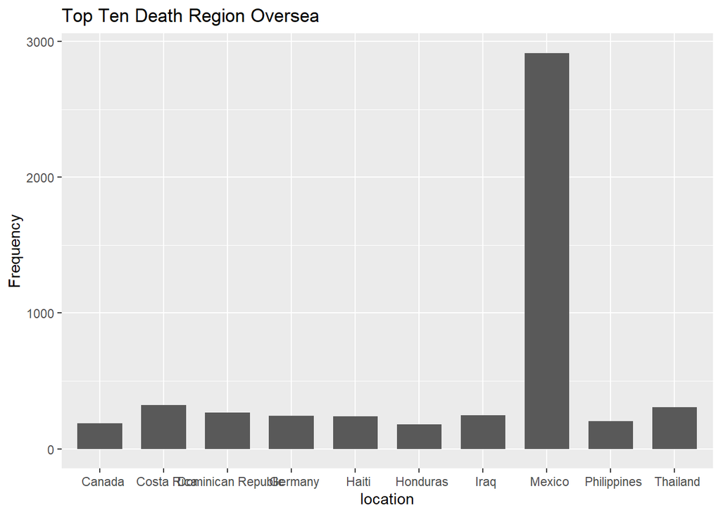

**Description** : The bar chart have list out the top 10 region that most U.S citizens die over sea. The purpose of the graph is to shows the danger of each region so people can avoid to travel to these location on the graph. As the graph shows, Mexico have approximately ten times higher than the other.

**Pie Chart**

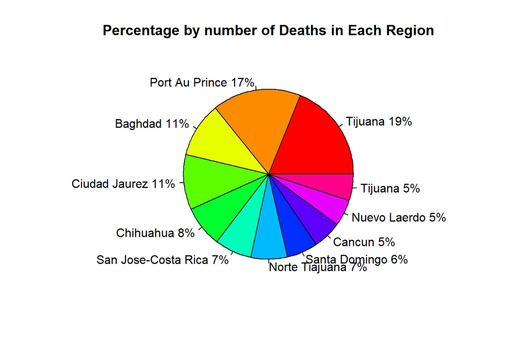

**Scatter Plot**

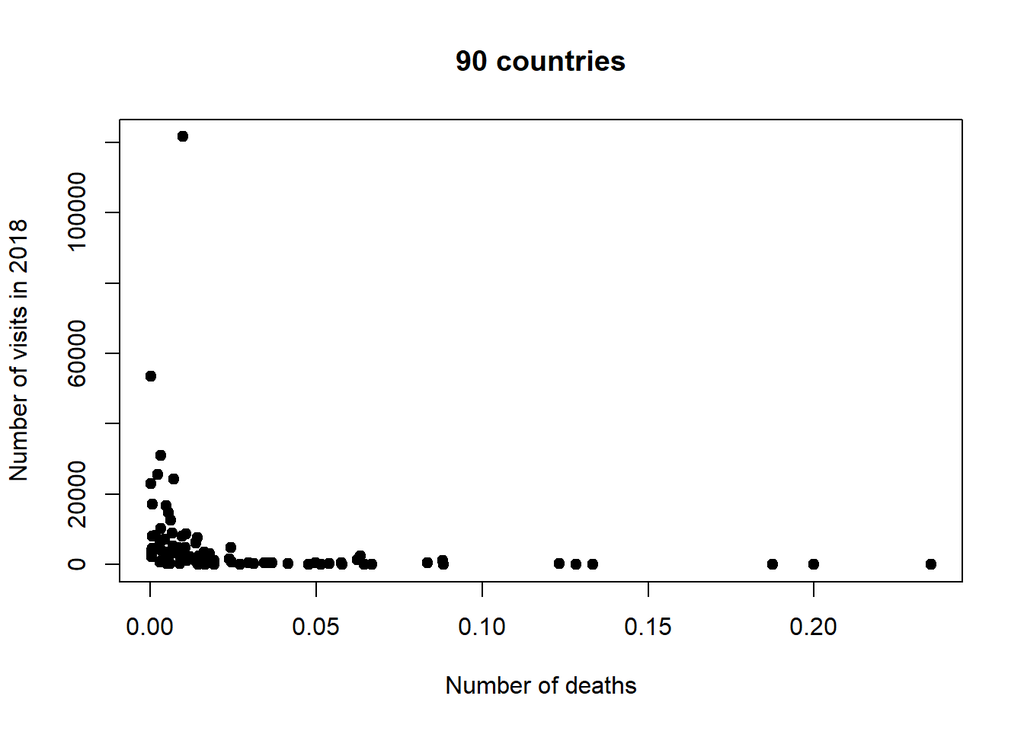

**References**

Baker, Td, et al. “The Uncounted Dead: American Civilians Dying Overseas.” Public Health Reports (1974), vol. 107, no. 2, Office of the Assistant Secretary for Health, 1992, pp. 155–59.

Garrett, Kelly. “U.S. Citizen Deaths Overseas.” Data.world, 19 Sept. 2018, https://data.world/kgarrett/us-citizen-deaths-overseas/workspace/file?filename=2002-10-2018-06.csv.

Hargarten, Stephen W., et al. “Overseas Fatalities of United States Citizen Travelers: An Analysis of Deaths Related to International Travel.” Annals of Emergency Medicine, vol. 20, no. 6, Mosby, Inc, 1991, pp. 622–26, https://doi.org/10.1016/S0196-0644(05)82379-0.

Kiefer, Kit. “2022 Safest Countries for Travel.” Berkshire Hathaway Travel Protection, 9 Dec. 2021, https://www.bhtp.com/blog/safest-places-to-travel.